# Самостоятельная работа. Многоуровневая логистическая регрессия

# 1 Подключите пакеты, которые мы использовали на семинаре.

```r
library(rio)
library(tidyverse)
library(skimr)
library(sjPlot)
library(lme4)
library(lmerTest)
library(lattice)
library(merTools)
library(caret)
library(margins)
library(plotROC)
library(ggeffects)
```

# 2 Подготовьте базу данных

Используем базу `timss15_math.csv` и подготовим ее к работе.

```r
mydata <- import("timss15_math.csv")

mydata$area <- as.factor(mydata$area)
mydata$itsex <- as.factor(mydata$itsex)
mydata$like_math <- as.factor(mydata$like_math)
mydata$par_edu <- as.factor(mydata$par_edu)
mydata$bsdgsb <- as.factor(mydata$bsdgsb)
mydata$bull_scl <- as.numeric(mydata$bull_scl)
mydata$conf_math_scl <- as.numeric(mydata$conf_math_scl)
mydata$city <- fct_collapse(mydata$area, urban = c("Urban, densely populated", "Medium size city or large town"), other = c("Suburban, on fringe of urban area", "Remote rural", "Small town or village"))

mydata$par_edu[mydata$par_edu == "Unknown"] <- NA
mydata$par_edu[mydata$par_edu == "Don't know"] <- NA

mydata$par_edu <- fct_collapse(mydata$par_edu, higher = c("Don't know", "Higher", "Unknown"), nohigher = "No higher")

mydata$conf_math_sd <- (mydata$conf_math - mean(mydata$conf_math, na.rm = T)) / sd(mydata$conf_math, na.rm = T)

mydata$bsdgsb[mydata$bsdgsb == "Omitted or invalid"] <- NA

mydata$bull <- fct_collapse(mydata$bsdgsb, no = c( "Almost Never", "Omitted or invalid"),  yes = c("About Weekly", "About Monthly"))

table(mydata$bull)
```

```
##
##  yes   no
## 1632 3126
```

```r
mydata2 <- mydata %>% filter(!is.na(bull)) %>% filter(!is.na(par_edu))    %>% filter(!is.na(conf_math_sd))
```

# 3 Проверьте связь факта буллинга с полом ученика и образованием его родителей

Постройте таблицу сопряженности для пола и факта буллинга. Кто чаще подвергается буллингу?

```r
# Вспомним команду sjt.xtab из первого семинара
sjt.xtab(mydata$itsex, mydata$bull, show.na = F,
         var.labels = c('sex','bulling'),
         show.cell.prc = TRUE,show.row.prc = TRUE)
```

| sex | bulling |  | Total |  |
| --- | --- | --- | --- | --- |
|  | yes | no |  |  |
| Female | 762 33.3 % 16 % | 1527 66.7 % 32.1 % |  | 2289 100 % 48.1 % |
| Male | 870 35.2 % 18.3 % | 1599 64.8 % 33.6 % | 2469 100 % 51.9 % |  |
| Total | 1632 34.3 % 34.3 % | 3126 65.7 % 65.7 % | 4758 100 % 100 % |  |

И среди мальчиков, и среди девочек примерно одинаковый процент учащихся подвергается буллингу (ок. 35%)

Постройте таблицу сопряженности для образования родителей и факта буллинга. Кто чаще подвергается буллингу?

```r
sjt.xtab(mydata$par_edu, mydata$bull, show.na = F,
         var.labels = c("Parents' higher education",'Bulling'),
         show.cell.prc = TRUE,show.row.prc = TRUE)
```

| Parents’ higher education | Bulling |  | Total |  |
| --- | --- | --- | --- | --- |
|  | yes | no |  |  |
| higher | 666 33.7 % 16.1 % | 1308 66.3 % 31.6 % |  | 1974 100 % 47.7 % |
| nohigher | 724 33.5 % 17.5 % | 1435 66.5 % 34.7 % | 2159 100 % 52.2 % |  |
| Total | 1390 33.6 % 33.6 % | 2743 66.4 % 66.4 % | 4133 100 % 100 % |  |

Такая же тенденция среди учащихся с разным образованием родителей: буллинг безжалостен и к одним, и ко вторым.

# 4 Оцените две простых (немногоуровневых) логистических модели

Для начала оцените модель с фактом буллинга в качестве зависимой переменной и интеракцией между полом и образованием родителей в качестве независимых

```r
model1 <- glm(data = mydata2, fct_relevel(mydata2$bull, "no", "yes") ~  par_edu*itsex, family = binomial(link = 'logit'), na.action = na.exclude )
summary(model1)
```

```
##
## Call:
## glm(formula = fct_relevel(mydata2$bull, "no", "yes") ~ par_edu *
##     itsex, family = binomial(link = "logit"), data = mydata2,
##     na.action = na.exclude)
##
## Deviance Residuals:
##     Min       1Q   Median       3Q      Max
## -0.9602  -0.9111  -0.8947   1.4115   1.5490
##
## Coefficients:
##                           Estimate Std. Error z value Pr(>|z|)
## (Intercept)               -0.84107    0.07201 -11.680  < 2e-16 ***
## par_edunohigher            0.17632    0.09604   1.836  0.06638 .
## itsexMale                  0.30592    0.09618   3.181  0.00147 **
## par_edunohigher:itsexMale -0.35005    0.13263  -2.639  0.00831 **
## ---
## Signif. codes:  0 '***' 0.001 '**' 0.01 '*' 0.05 '.' 0.1 ' ' 1
##
## (Dispersion parameter for binomial family taken to be 1)
##
##     Null deviance: 5271.5  on 4127  degrees of freedom
## Residual deviance: 5261.1  on 4124  degrees of freedom
## AIC: 5269.1
##
## Number of Fisher Scoring iterations: 4
```

В модели значимы два коэффициента: для пола ученика и для интеракции пола и образования родителей. Мальчики в целом имеют более высокую вероятность быть подвергнутыми буллингу. При этом у мальчиков из семей, где родители не имеют ВО, такая вероятность ниже, чем у мальчиков из семей, где родители имеют ВО.

Проинтерпретируйте предельные эффекты

```r
marg_1 <- margins(model1)
summary(marg_1)
```

```
##           factor     AME     SE       z      p   lower  upper
##        itsexMale  0.0274 0.0147  1.8634 0.0624 -0.0014 0.0561
##  par_edunohigher -0.0014 0.0147 -0.0941 0.9250 -0.0302 0.0274
```

[figure not shown]

```r
plot(marg_1)
```

В предельных эффектах не считается коэффициент интеракции, так что мы можем увидеть, что без него обе переменные сами по себе не показывают значимой связи с фактом буллинга.

Постройте и проинтерпретируйте график с предсказанными значениями по обеим переменным

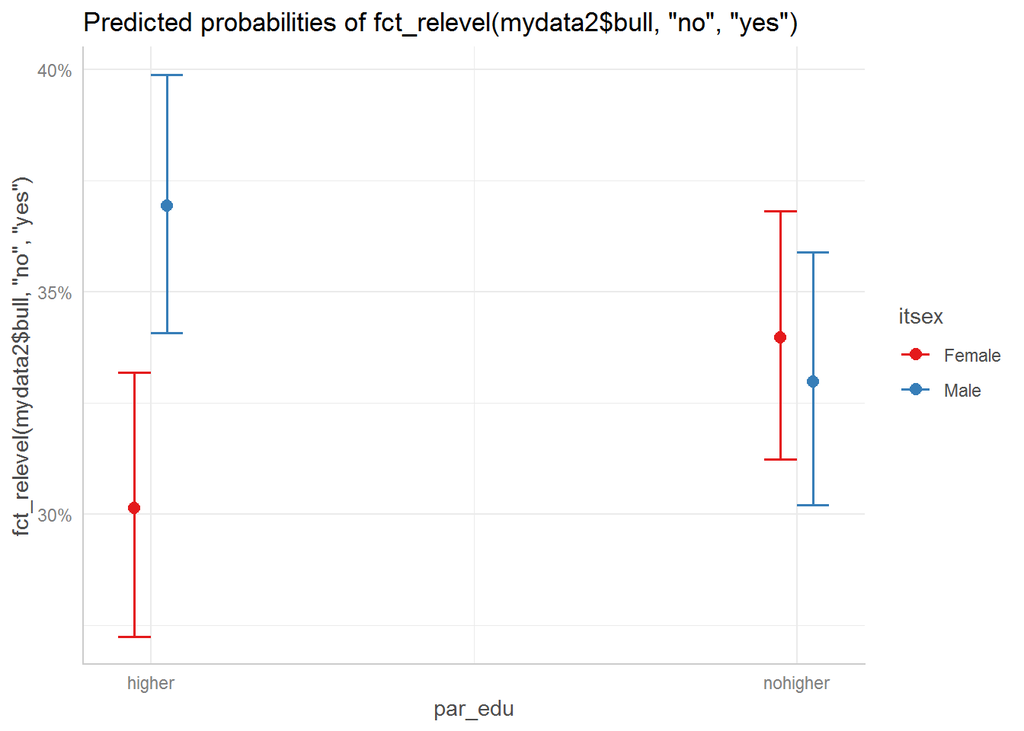

```r
plot(ggpredict(model1, terms = c( "par_edu", "itsex")))
```

На графике видно, что разница между мальчиками и девочками существует только в том случае, если их родители имеют высшее образование - таких мальчиков булят чаще, чем таких девочек.

Во вторую модель включим контрольные переменные. Проинтерпретируйте результаты.

```r
model2 <- glm(data = mydata2, fct_relevel(mydata2$bull, "no", "yes") ~ par_edu*itsex + conf_math_sd + city, family = binomial(link = 'logit'), na.action = na.exclude )
summary(model2)
```

```
##
## Call:
## glm(formula = fct_relevel(mydata2$bull, "no", "yes") ~ par_edu *
##     itsex + conf_math_sd + city, family = binomial(link = "logit"),
##     data = mydata2, na.action = na.exclude)
##
## Deviance Residuals:
##     Min       1Q   Median       3Q      Max
## -1.4123  -0.9233  -0.8234   1.3799   1.9366
##
## Coefficients:
##                           Estimate Std. Error z value Pr(>|z|)
## (Intercept)               -0.80619    0.07531 -10.705  < 2e-16 ***
## par_edunohigher            0.07705    0.09852   0.782 0.434173
## itsexMale                  0.34526    0.09731   3.548 0.000388 ***
## conf_math_sd              -0.29764    0.03529  -8.435  < 2e-16 ***
## cityother                 -0.03695    0.06973  -0.530 0.596182
## par_edunohigher:itsexMale -0.33658    0.13385  -2.515 0.011916 *
## ---
## Signif. codes:  0 '***' 0.001 '**' 0.01 '*' 0.05 '.' 0.1 ' ' 1
##
## (Dispersion parameter for binomial family taken to be 1)
##
##     Null deviance: 5271.5  on 4127  degrees of freedom
## Residual deviance: 5186.3  on 4122  degrees of freedom
## AIC: 5198.3
##
## Number of Fisher Scoring iterations: 4
```

Помимо прежних значимых коэффициентов, значимую связь также показал индекс уверенности в математике - чем выше уровень уверенности, тем ниже вероятность буллинга.

Проинтерпретируйте предельные эффекты. Сравните с результатами, полученными в предыдущей модели

```r
marg_2 <- margins(model2)
summary(marg_2)
```

```
##           factor     AME     SE       z      p   lower   upper
##        cityother -0.0081 0.0152 -0.5306 0.5957 -0.0379  0.0217
##     conf_math_sd -0.0651 0.0075 -8.6968 0.0000 -0.0797 -0.0504
##        itsexMale  0.0369 0.0146  2.5307 0.0114  0.0083  0.0655
##  par_edunohigher -0.0215 0.0151 -1.4271 0.1535 -0.0510  0.0080
```

Постройте и проинтерпретируйте график с предсказанными значениями по всем трем переменным

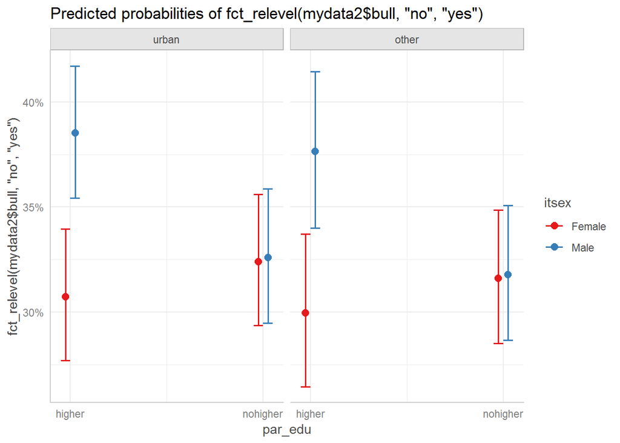

```r
plot(ggpredict(model2, terms = c("par_edu", "itsex", "city")))
```

Сделайте для каждого наблюдения предсказание с помощью модели, в какую группу он попадет - подвергающихся буллингу или нет. Проинтерпретируйте результаты.

```r
mydata2$pred <- predict(model2, type = 'resp')
summary(mydata2$pred)
```

```
##    Min. 1st Qu.  Median    Mean 3rd Qu.    Max.
##  0.1486  0.2953  0.3375  0.3362  0.3743  0.6311
```

```r
mydata2$pred2 <- cut(mydata2$pred, breaks=c(-Inf, 0.5, Inf), labels=c("no", "yes"))
table(mydata2$pred2, mydata2$bull)
```

```
##
##        yes   no
##   no  1355 2716
##   yes   33   24
```

Постройте ROC кривую и опишите её

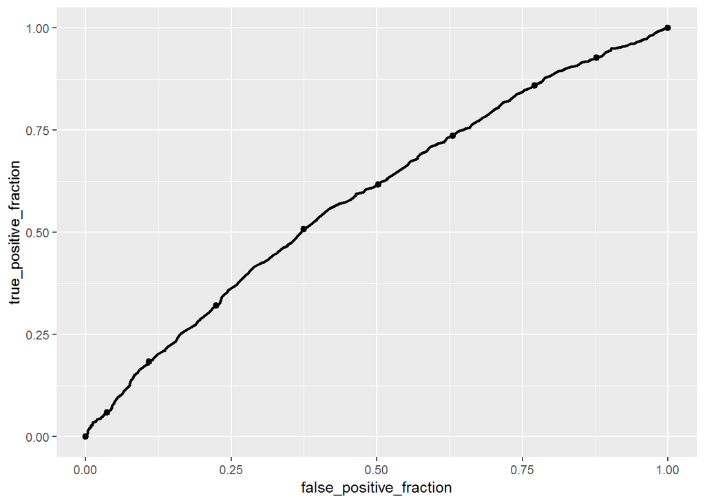

```r
ggplot(mydata2,  aes(d = bull, m = pred)) +
  geom_roc(labels = F)
```

ROC - кривая близка к диагонали - модель плохо предсказывает данные.

# 5 Постройте и опишите две многоуровневых модели: random intercept и random slope, random intercept correlated

Постройте и опишите модель, аналогичную предыдущей, но многоуровневую random intercept, визуализируйте случайные эффекты

```r
hlm_1 <- glmer(data = mydata2, fct_relevel(mydata2$bull, "no", "yes") ~ par_edu*itsex + conf_math_sd + city  + (1 | idclass), family = binomial(link = 'logit'), na.action = na.exclude)
summary(hlm_1)
```

```
## Generalized linear mixed model fit by maximum likelihood (Laplace
##   Approximation) [glmerMod]
##  Family: binomial  ( logit )
## Formula:
## fct_relevel(mydata2$bull, "no", "yes") ~ par_edu * itsex + conf_math_sd +
##     city + (1 | idclass)
##    Data: mydata2
##
##      AIC      BIC   logLik deviance df.resid
##   5142.8   5187.1  -2564.4   5128.8     4121
##
## Scaled residuals:
##     Min      1Q  Median      3Q     Max
## -1.7856 -0.7111 -0.5668  1.1250  2.9219
##
## Random effects:
##  Groups  Name        Variance Std.Dev.
##  idclass (Intercept) 0.2391   0.489
## Number of obs: 4128, groups:  idclass, 221
##
## Fixed effects:
##                           Estimate Std. Error z value Pr(>|z|)
## (Intercept)               -0.84869    0.09045  -9.383  < 2e-16 ***
## par_edunohigher            0.10072    0.10388   0.970 0.332262
## itsexMale                  0.34968    0.10102   3.462 0.000537 ***
## conf_math_sd              -0.30387    0.03667  -8.287  < 2e-16 ***
## cityother                 -0.06462    0.09958  -0.649 0.516378
## par_edunohigher:itsexMale -0.37129    0.13890  -2.673 0.007516 **
## ---
## Signif. codes:  0 '***' 0.001 '**' 0.01 '*' 0.05 '.' 0.1 ' ' 1
##
## Correlation of Fixed Effects:
##             (Intr) pr_dnh itsxMl cnf_m_ ctythr
## par_ednhghr -0.600
## itsexMale   -0.622  0.539
## conf_mth_sd -0.005  0.106 -0.063
## cityother   -0.365 -0.107 -0.011  0.016
## pr_dnhghr:M  0.455 -0.702 -0.722  0.001  0.000
```

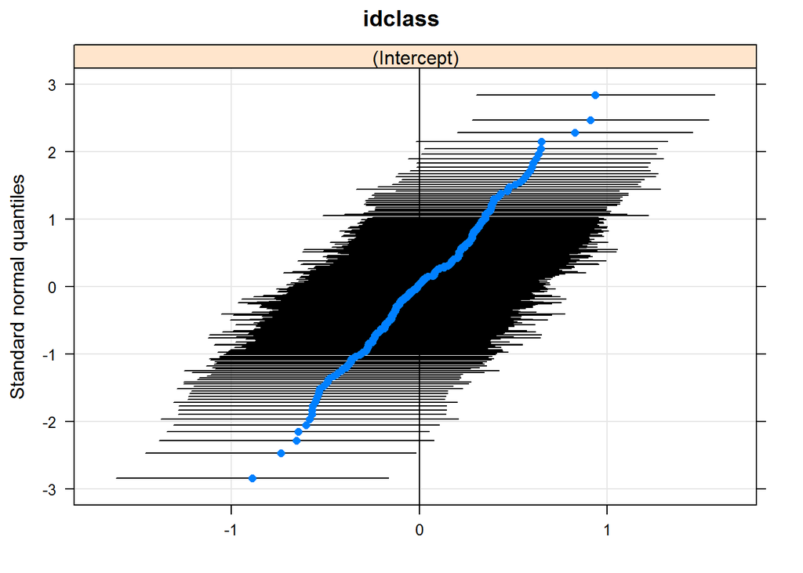

```r
qqmath(ranef(hlm_1, condVar = TRUE))
```

Все коэффициенты для фиксированных эффектов остались прежними; интерцепт варьируется достаточно сильно.

Постройте и опишите модель random slope, random intercept, визуализируйте случайные эффекты

```r
hlm_2 <- glmer(data = mydata2, fct_relevel(mydata2$bull, "no", "yes")  ~ par_edu*itsex + conf_math_scl + city  + (par_edu | idclass), family = binomial(link = 'logit'), na.action = na.exclude)
summary(hlm_2)
```

```
## Generalized linear mixed model fit by maximum likelihood (Laplace
##   Approximation) [glmerMod]
##  Family: binomial  ( logit )
## Formula:
## fct_relevel(mydata2$bull, "no", "yes") ~ par_edu * itsex + conf_math_scl +
##     city + (par_edu | idclass)
##    Data: mydata2
##
##      AIC      BIC   logLik deviance df.resid
##   5146.5   5203.4  -2564.3   5128.5     4119
##
## Scaled residuals:
##     Min      1Q  Median      3Q     Max
## -1.7349 -0.7096 -0.5656  1.1223  2.9639
##
## Random effects:
##  Groups  Name            Variance Std.Dev. Corr
##  idclass (Intercept)     0.272539 0.52205
##          par_edunohigher 0.003771 0.06141  -0.98
## Number of obs: 4128, groups:  idclass, 221
##
## Fixed effects:
##                           Estimate Std. Error z value Pr(>|z|)
## (Intercept)                0.65370    0.20424   3.201 0.001371 **
## par_edunohigher            0.11014    0.10547   1.044 0.296337
## itsexMale                  0.35112    0.10150   3.459 0.000541 ***
## conf_math_scl             -0.15274    0.01842  -8.294  < 2e-16 ***
## cityother                 -0.06320    0.09939  -0.636 0.524850
## par_edunohigher:itsexMale -0.37118    0.13896  -2.671 0.007562 **
## ---
## Signif. codes:  0 '***' 0.001 '**' 0.01 '*' 0.05 '.' 0.1 ' ' 1
##
## Correlation of Fixed Effects:
##             (Intr) pr_dnh itsxMl cnf_m_ ctythr
## par_ednhghr -0.371
## itsexMale   -0.221  0.537
## cnf_mth_scl -0.891  0.099 -0.065
## cityother   -0.178 -0.098 -0.010  0.015
## pr_dnhghr:M  0.202 -0.692 -0.725  0.001 -0.001
## convergence code: 0
## Model failed to converge with max|grad| = 0.00864022 (tol = 0.001, component 1)
```

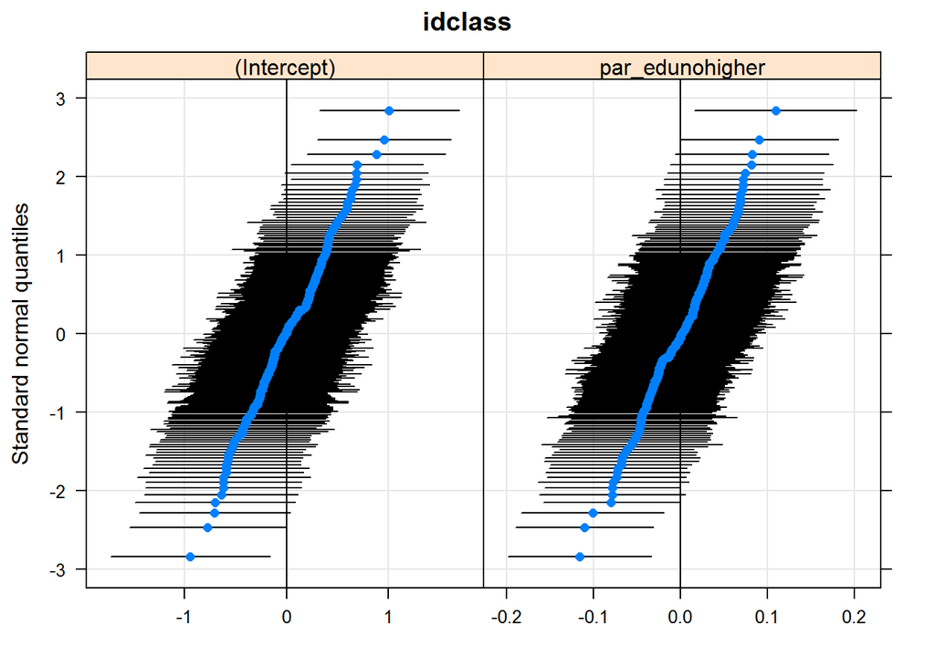

```r
qqmath(ranef(hlm_2, condVar = TRUE))
```

Построена модель random slope, random intercept correlated. В фиксированных эффектах ничего не изменилось, а slope для образования родителей варьируется незначительно.

Сделайте для каждого наблюдения предсказание с помощью последней модели, в какую группу он попадет - подвергающихся буллингу или нет, и постройте ROC - кривую. Проинтерпретируйте результаты.

```r
mydata2$predhlm <- predict(hlm_2, type = 'resp')
summary(mydata2$predhlm)
```

```
##    Min. 1st Qu.  Median    Mean 3rd Qu.    Max.
## 0.07278 0.26107 0.32779 0.33419 0.40102 0.75061
```

```r
mydata2$pred2hlm <- cut(mydata2$predhlm, breaks=c(-Inf, 0.5, Inf), labels=c("no", "yes"))
table(mydata2$pred2hlm, mydata2$bull)
```

```
##
##        yes   no
##   no  1241 2650
##   yes  147   90
```

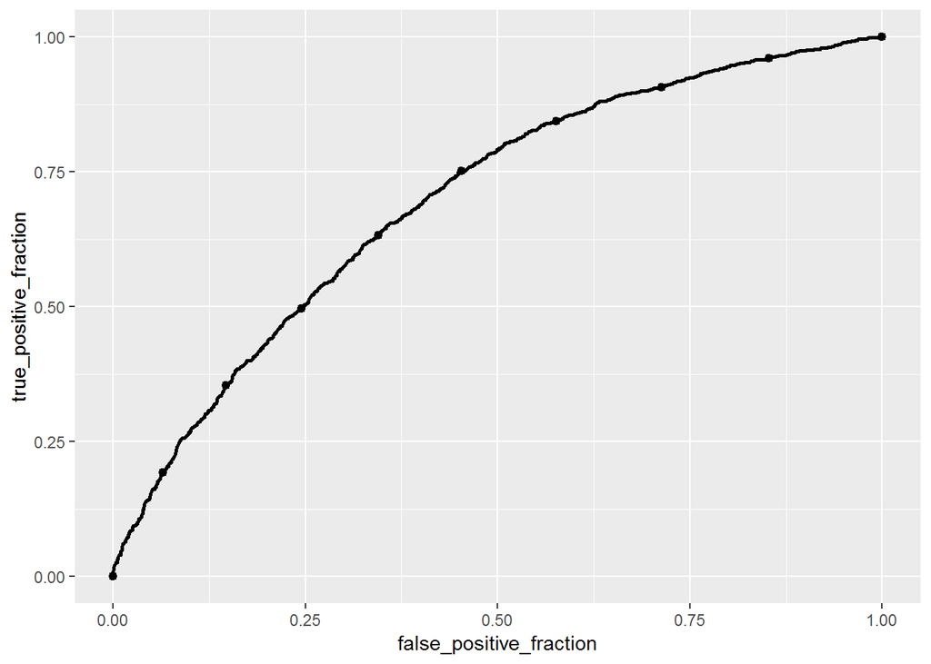

```r
ggplot(mydata2,  aes(d = bull, m = predhlm)) +
  geom_roc(labels = F)
```

Предсказания стали немного точнее, ROC - кривая стала немного менее диагональной )

Постройте и проинтерпретируйте график с предсказанными значениями по всем трем переменным

```
## Could not compute confidence intervals, probably due to memory allocation problems. Try using the `n`-tag (with different values) to reduce number of predicted values, e.g. `terms="par_edu [n=10]"`.
```

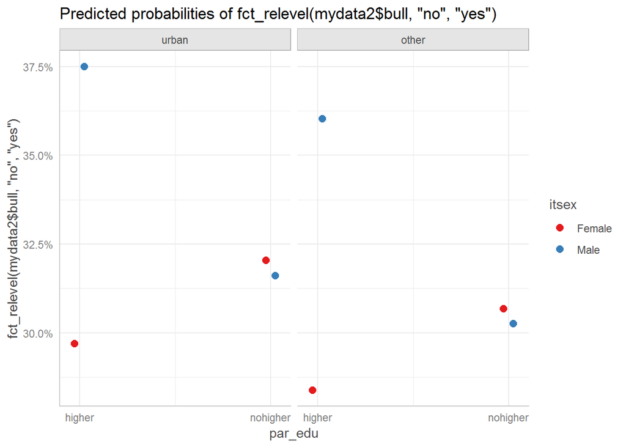

```r
plot(ggpredict(hlm_2, terms = c("par_edu", 'itsex', 'city')))
```

*Когда я готовила это задание, все работало и доверительные интервалы строились, честно. В целом тут разница выросла немного для учащихся с родителям с высшим образованием*

Выберите наилучшую модель

```r
anova(hlm_1, hlm_2)
```

```
## Data: mydata2
## Models:
## hlm_1: fct_relevel(mydata2$bull, "no", "yes") ~ par_edu * itsex + conf_math_sd +
## hlm_1:     city + (1 | idclass)
## hlm_2: fct_relevel(mydata2$bull, "no", "yes") ~ par_edu * itsex + conf_math_scl +
## hlm_2:     city + (par_edu | idclass)
##       Df    AIC    BIC  logLik deviance  Chisq Chi Df Pr(>Chisq)
## hlm_1  7 5142.8 5187.1 -2564.4   5128.8
## hlm_2  9 5146.5 5203.4 -2564.3   5128.5 0.3113      2     0.8559
```

Обе модели одинаково хорошо (на самом деле плохо) описывают данные.